# Análise dos dados de temperatura e chuva de João Pessoa e Campina Grande

## Qual foi o mês de São João mais frio entre 2008 e 2018, em Campina Grande?

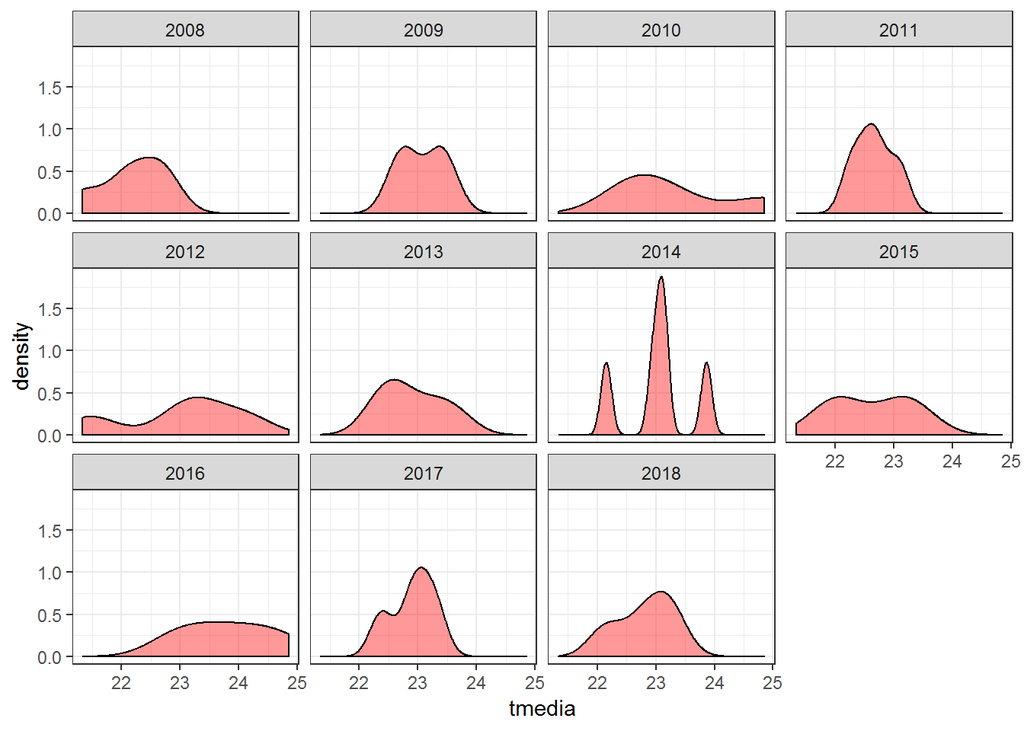

```r
cg_saojoao = climas %>%
    filter(cidade == "Campina Grande", mes == 6, ano >= 2008, ano < 2019)

cg_saojoao %>%
    ggplot(aes(x = tmedia)) +
    geom_density(alpha = .4, fill = "red") +
    facet_wrap(~ ano)
```

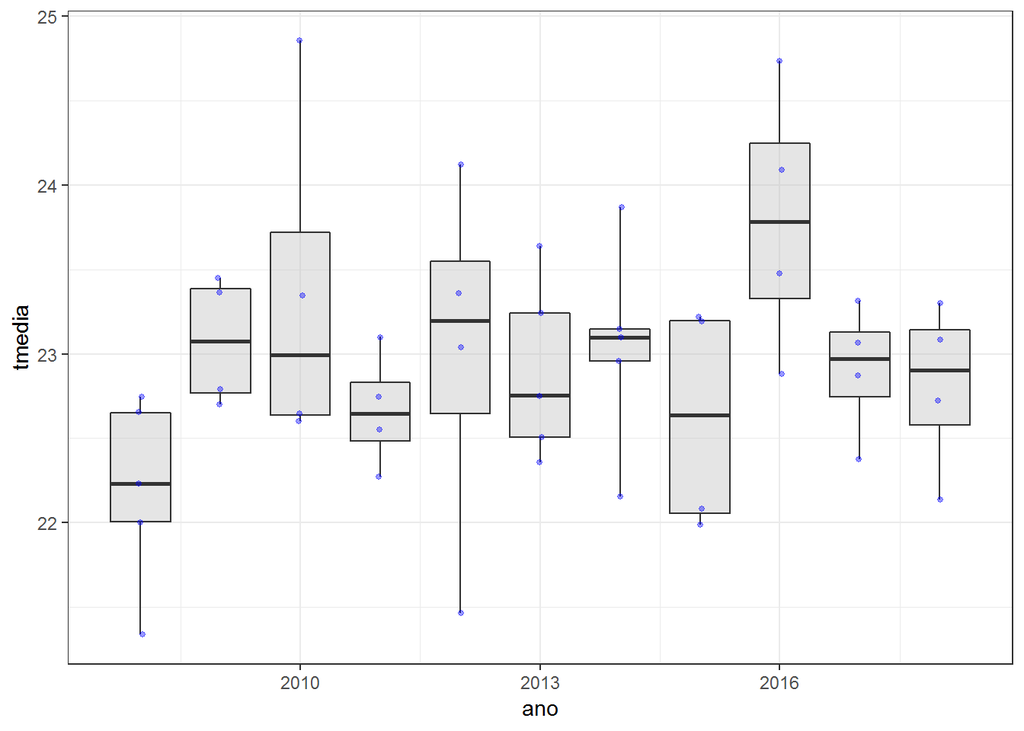

```r
cg_saojoao = climas %>%
    filter(cidade == "Campina Grande", mes == 6, ano >= 2008, ano < 2019)

cg_saojoao %>%
    ggplot(aes(x = ano, y = tmedia, group = ano)) +
    geom_boxplot(alpha = .4, fill = "gray", coef = 1000) +
    geom_jitter(
        width = .03,
        alpha = .4,
        size = 1,
        color = "blue"
    )
```

# Análises da Chuva

## Observando os dados dos últimos 10 anos, chove mais em Campina Grande ou em João Pessoa?

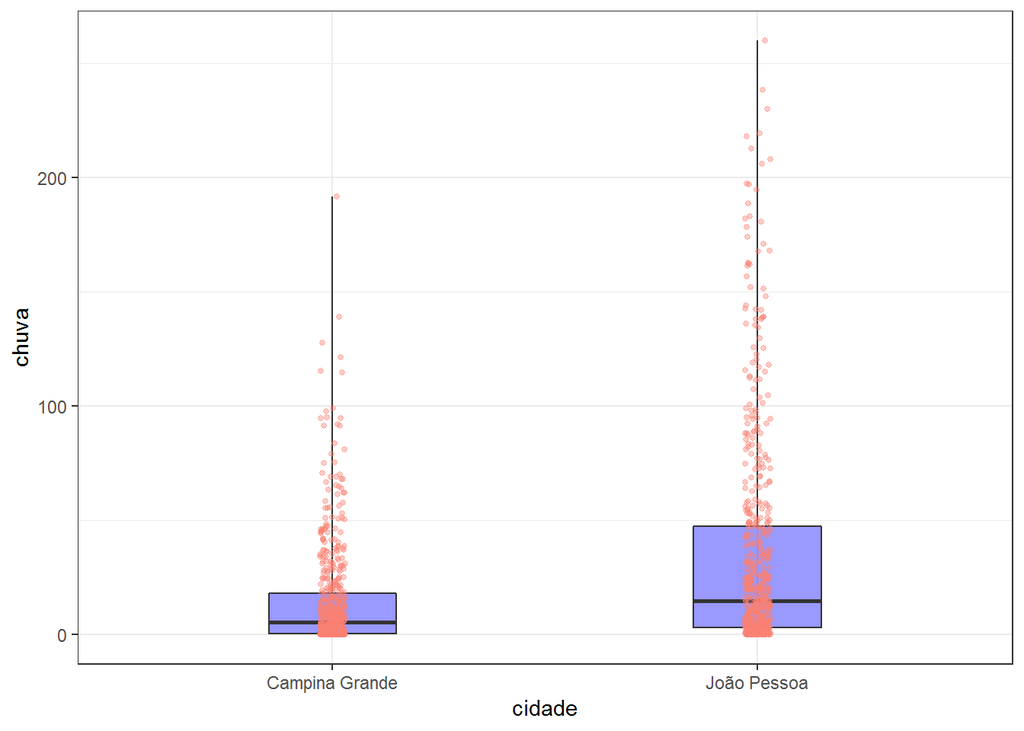

```r
chuva = climas %>%
    filter(ano >= 2008, ano < 2019)

chuva %>%
    ggplot(aes(x = cidade, y = chuva)) +
    geom_boxplot(alpha = .4, width = .3, fill = "blue", coef = 1000) +
    geom_jitter(
        width = .03,
        alpha = .4,
        size = 1,
        color = "salmon"
    )
```

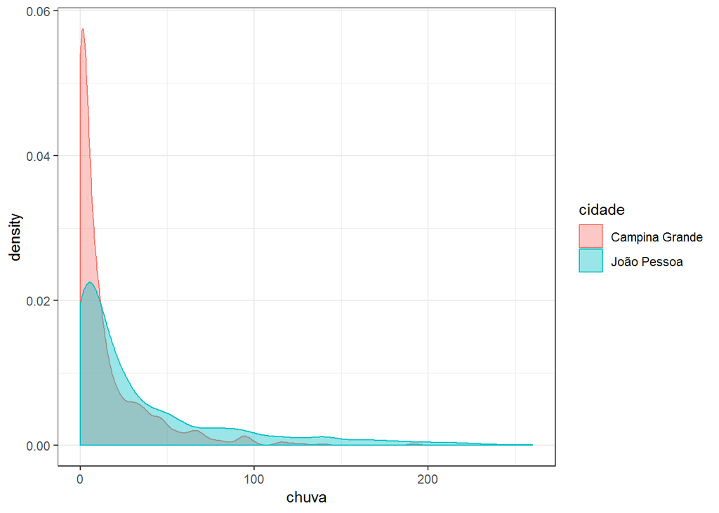

```r
chuva %>%
    ggplot(aes(x = chuva, color = cidade, fill = cidade)) +
    geom_density(alpha = .4)
```

O primeiro gráfico apresenta os dados da variável chuva em relação às cidades de Campina Grande e João Pessoa, em que é possível observar que os dados das duas cidades, e as medianas desses dados apresentam uma maior concentração próximo ao valor 0, bem como é possível perceber que os dados de ambas as cidades apresentam valores extremos ou discrepantes. Apesar de algumas semelhanças no comportamento dos dados das duas cidades é notório observar que os dados de João Pessoa apresentam uma quantidade superior de valores miores de chuva em relação aos dados de Campina Grande, levando a crer que a maior incidência de chuva é na cidade de João Pessoa.

## A distribuição ou o comportamento dos dados de chuva das cidades de Campina Grande e João Pessoa é diferente em meses específicos, observando-se os dados de 2008 à 2018?

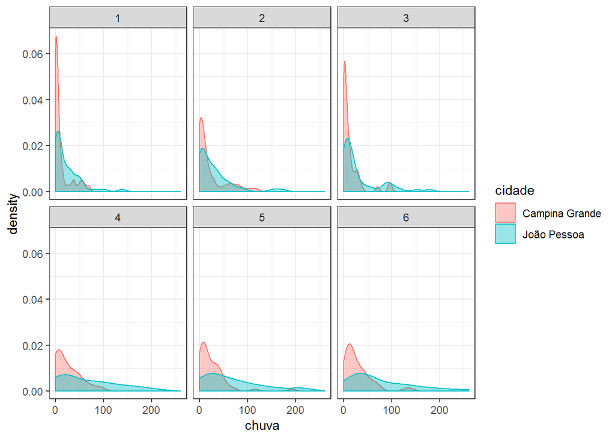

```r
chuva_meses1a6 = climas %>%
    filter(mes >= 1, mes <= 6, ano >= 2008, ano < 2019)

chuva_meses1a6 %>%
    ggplot(aes(x = chuva, color = cidade, fill = cidade)) +
    geom_density(alpha = .4) +
    facet_wrap(~ mes)
```

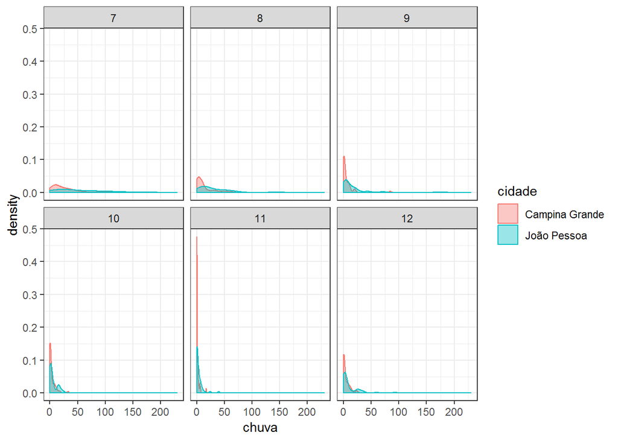

```r
chuva_meses7a12 = climas %>%
    filter(mes >= 7, mes <= 12, ano >= 2008, ano < 2019)

chuva_meses7a12 %>%
    ggplot(aes(x = chuva, color = cidade, fill = cidade)) +
    geom_density(alpha = .4) +
    facet_wrap(~ mes)
```

A primeira visualização é composta pela densidade dos valores de chuva ao longo de 2008 e 2018 divido por mês. Foram feitos dois gráficos, cada um com dados de um semestre para facilitar a visualização das característiicas dos dados. Nesta primeira visualização observa-se que todos os meses apresentam distribuição assimétrica positiva, contendo a cauda maior a direita, ou seja, a maior incidência é de valores baixos, para as duas cidades. É possível observar também que os meses que compreendem as estações primavera e verão (Outubro à Março) apresentam uma maior incidência de valores próximos ou igual a 0, principalmente em Campina Grande. Já os meses que abrangem as estações outono e inverno (Maio à Setembro), apresentam uma maior incidência de valores acima de 0, principalmente nos dados de João Pessoa.

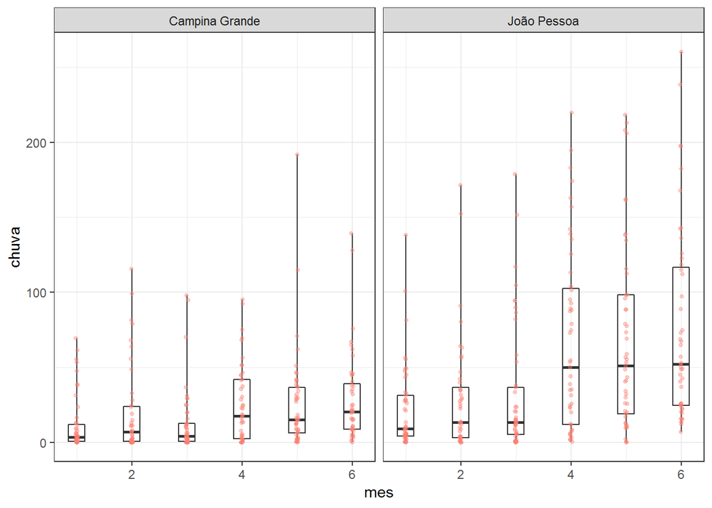

```r
chuva_meses1a6 %>%
    ggplot(aes(x = mes, y = chuva, group = mes)) +
    geom_boxplot(alpha = .4, width = .3, coef = 1000) +
    geom_jitter(
        width = .02,
        alpha = .4,
        size = 1,
        color = "salmon"
    ) +
    facet_wrap(~ cidade)
```

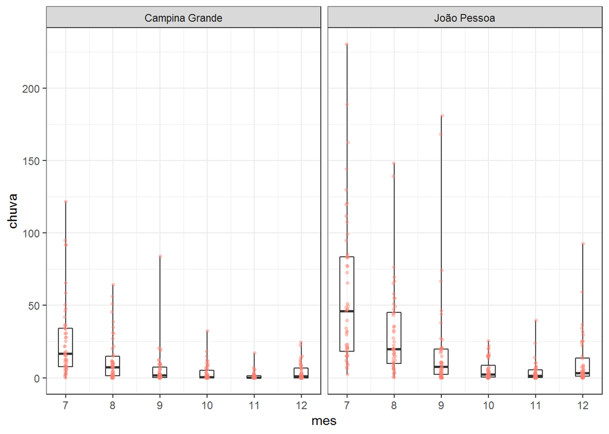

```r
chuva_meses7a12 %>%
    ggplot(aes(x = mes, y = chuva, group = mes)) +
    geom_boxplot(alpha = .4, width = .3, coef = 1000) +
    geom_jitter(
        width = .02,
        alpha = .4,
        size = 1,
        color = "salmon"
    ) +
    facet_wrap(~ cidade)
```

A segunda visualização por boxplots dos dados da variável chuva em relação os meses. Também foram gerados dois gráficos contento um semestra cada. Nesta visualização é possível ver de forma clara os comportamentos apotados no gráfico anterior. Os meses que compreendem o período do outono e o inverno apresentam uma amplitude maior em relação aos dados do período da primavera e do verão.